# CreditCardFraud

Trying to reproduce results from and expert kaggler kernel:

https://www.kaggle.com/nschneider/gbm-vs-xgboost-vs-lightgbm

```r
credit.card.data = read.csv("./data/credit_card.csv")
```

[output not shown]

```r
test = credit.card.data[train.test.split == 2]
```

[output not shown]

```r
train
```

[output not shown]

The author of the source notebook starts with the gradient boosting technique via the GBM package. It’s been a while since I’ve read over gradient boosting, so re-summarizing here:

Train many “weak” models that are not good classifiers on their own, but that have *some* significance along different axes. They don’t have to be great models, just have some valid signal (and ideally not be overlapping in what signals they capture).

Specifically, train weak learners progressively on specifically the examples that we have not classified correctly with prior weak learners.

This still requires some way to combine them. You could just average the votes from the learners, but this would not be very informative. The learners are weighted according to how well they do on their respective passes.

That’s about as deep as I have time to review at the moment so let’s implement:

```r
gbm.model <- gbm(Class ~ .
                 , distribution = "bernoulli"
                 , data = rbind(train, test)
                 , n.trees = 500
                 , interaction.depth = 3
                 , n.minobsinnode = 100
                 , shrinkage = 0.01
                 , bag.fraction = 0.5
                 , train.fraction = nrow(train)/(nrow(train) + nrow(test)))
```

And let’s chart the quality of the predictions:

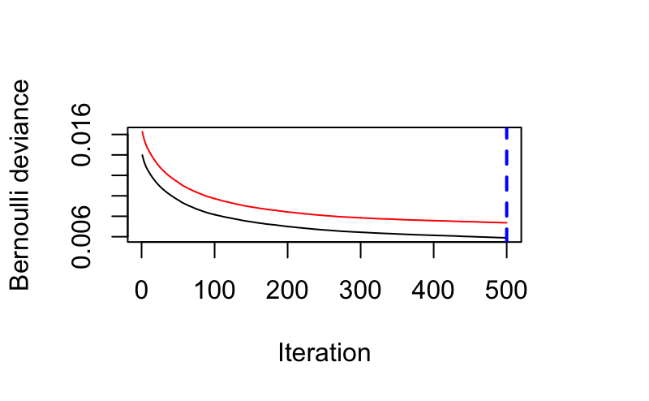

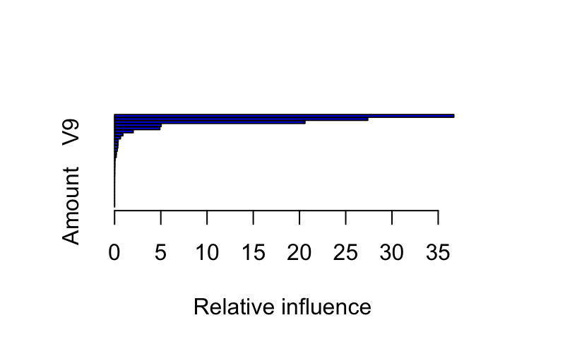

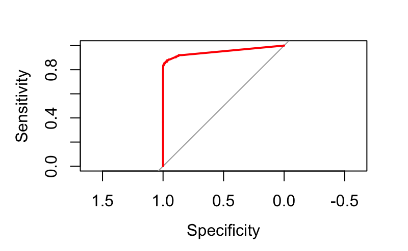

```r
best.iter = gbm.perf(gbm.model, method = "test")
gbm.feature.imp = summary(gbm.model, n.trees = best.iter)

gbm.test = predict(gbm.model, newdata=test, n.trees=best.iter)
auc.gbm = roc(test$Class, gbm.test, plot=TRUE, col="red")
```